# **Задание 7**

Андрей Кедич

## Основы статистики

Подключение библиотек:

```r
library(tidyverse)
library(googlesheets4)
library(rlang)
library(lubridate)
```

Загрузка каталога метеостанций:

```r
catalog <- read_sheet('1Q6HCY4jxiYefjPdWrN5erwgEee-Gz_BywqZW2mQcftw')
```

Загрузка и выполнение преобразований с помощью пайп-оператора данных по метеостанциям:

```r
meteo_data <- lapply(as.character(catalog$ID), function(X) read_sheet('1FWC_YBrlINnjR5POC2kxa_LnLC7n5fFA90oNA7dLTP0', sheet = X, col_types = 'ccncccnninncnnnnncc')) %>%
  set_names(catalog$ID) %>%
  bind_rows(.id = 'id') %>%
  mutate(id = as.numeric(id)) %>%
  full_join(catalog, by = c('id' = 'ID')) %>%
  mutate(Datetime = as.POSIXct(Datetime)) %>%
  relocate(id, .before = NAME) %>%
  set_names(c('Datetime', 'Wdir', 'Wspd', 'Vis', 'Phen', 'Cloud', 'T', 'Td', 'F', 'Te', 'Tes', 'Comf', 'P', "Po", 'Tmin', 'Tmax', 'R', 'R24', 'S', 'ID', 'NAME', 'LON', 'LAT', 'H'))
```

Итоговая таблицы данных по метеостанциям:

```r
meteo_data
```

```
## # A tibble: 16,367 x 24
##    Datetime            Wdir   Wspd Vis   Phen  Cloud     T    Td     F    Te
##    <dttm>              <chr> <dbl> <chr> <chr> <chr> <dbl> <dbl> <int> <dbl>
##  1 2019-07-24 15:00:00 В         1 10 км слаб~ 9/9 ~  16.5  13.5    82    17
##  2 2019-07-24 18:00:00 штиль     0 10 км {лив~ 9/4 ~  15.6  14.5    93    15
##  3 2019-07-24 21:00:00 З         1 2000~ дымка 10/1~  14.7  14.5    99    15
##  4 2019-07-25 00:00:00 С         1 500 м туман ?/?    14.4  14.3    99    15
##  5 2019-07-25 03:00:00 СВ        1 500 м туман ?/?    14.7  14.6    99    15
##  6 2019-07-25 06:00:00 СВ        1 10 км дымк~ 9/8 ~  16.7  15.4    92    18
##  7 2019-07-25 09:00:00 ЮВ        1 10 км <NA>  9/9 ~  19.5  15.3    77    22
##  8 2019-07-25 12:00:00 В         1 10 км в по~ 9/9 ~  19.5  15.3    77    22
##  9 2019-07-25 15:00:00 СВ        1 10 км в по~ 9/9 ~  21.6  16.2    71    25
## 10 2019-07-25 18:00:00 С         1 10 км гроз~ 9/9 ~  17.7  17.2    97    19
## # ... with 16,357 more rows, and 14 more variables: Tes <dbl>, Comf <chr>,
## #   P <dbl>, Po <dbl>, Tmin <dbl>, Tmax <dbl>, R <dbl>, R24 <chr>, S <chr>,
## #   ID <dbl>, NAME <chr>, LON <dbl>, LAT <dbl>, H <dbl>
```

Фильтрация данных (только метеостанции Балчуг и Малое Сареево):

```r
filter_data <- meteo_data %>%
  filter(str_detect(NAME, 'Балчуг') | str_detect(NAME, 'Сареево'))
print(filter_data)
```

```
## # A tibble: 1,293 x 24
##    Datetime            Wdir   Wspd Vis   Phen  Cloud     T    Td     F    Te
##    <dttm>              <chr> <dbl> <chr> <chr> <chr> <dbl> <dbl> <int> <dbl>
##  1 2019-07-24 15:00:00 ЮЗ        1 4000~ слаб~ 10/1~  15.3  14.5    95    16
##  2 2019-07-24 18:00:00 штиль     0 4000~ дымк~ 9/8 ~  15.3  14.4    94    15
##  3 2019-07-24 21:00:00 штиль     0 4000~ дымка 8/5 ~  13.1  12.5    96    13
##  4 2019-07-25 00:00:00 СЗ        1 4000~ дымка 10/1~  13.7  13.2    97    14
##  5 2019-07-25 03:00:00 штиль     0 4000~ дымка 10/1~  14.8  14.4    97    14
##  6 2019-07-25 06:00:00 ЮВ        1 4000~ дымка 9/9 ~  18.2  16.6    90    20
##  7 2019-07-25 09:00:00 В         1 10 км <NA>  10/8~  21.2  14.7    66    24
##  8 2019-07-25 12:00:00 СВ        1 4000~ слаб~ 10/1~  17.9  16.8    93    19
##  9 2019-07-25 15:00:00 СВ        2 10 км {лив~ 9/9 ~  19.8  16.9    83    23
## 10 2019-07-25 18:00:00 С         1 4000~ дымк~ 10/6~  18.2  16.4    89    20
## # ... with 1,283 more rows, and 14 more variables: Tes <dbl>, Comf <chr>,
## #   P <dbl>, Po <dbl>, Tmin <dbl>, Tmax <dbl>, R <dbl>, R24 <chr>, S <chr>,
## #   ID <dbl>, NAME <chr>, LON <dbl>, LAT <dbl>, H <dbl>
```

Фильтрация данных (только ночные измерения 0:00 и 3:00):

```r
filter_data_night <- filter_data %>%
  filter(hour(Datetime) == 0 | hour(Datetime) == 3)
print(filter_data_night)
```

```
## # A tibble: 324 x 24
##    Datetime            Wdir   Wspd Vis   Phen  Cloud     T    Td     F    Te
##    <dttm>              <chr> <dbl> <chr> <chr> <chr> <dbl> <dbl> <int> <dbl>
##  1 2019-07-25 00:00:00 СЗ        1 4000~ дымка 10/1~  13.7  13.2    97    14
##  2 2019-07-25 03:00:00 штиль     0 4000~ дымка 10/1~  14.8  14.4    97    14
##  3 2019-07-26 00:00:00 СВ        1 4000~ дымка 9/8 ~  17.4  16.6    95    18
##  4 2019-07-26 03:00:00 СЗ        1 4000~ дымка 8/8 ~  17.1  16.5    96    18
##  5 2019-07-27 00:00:00 СЗ        1 4000~ дымка 10/6~  16.1  14.6    91    17
##  6 2019-07-27 03:00:00 СЗ        1 4000~ дымка 10/0~  15.5  14.8    96    16
##  7 2019-07-28 00:00:00 штиль     0 10 км <NA>  3/3 ~  18    15.1    83    18
##  8 2019-07-28 03:00:00 штиль     0 4000~ дымка 3/3 ~  16.8  15.8    94    17
##  9 2019-07-29 00:00:00 С        NA 10 км <NA>  1/1 ~  12.5   7.4    71    11
## 10 2019-07-29 03:00:00 СЗ        1 10 км <NA>  ясно   10.6   4.6    66    10
## # ... with 314 more rows, and 14 more variables: Tes <dbl>, Comf <chr>,
## #   P <dbl>, Po <dbl>, Tmin <dbl>, Tmax <dbl>, R <dbl>, R24 <chr>, S <chr>,
## #   ID <dbl>, NAME <chr>, LON <dbl>, LAT <dbl>, H <dbl>
```

Построение графика плотности распределения температур:

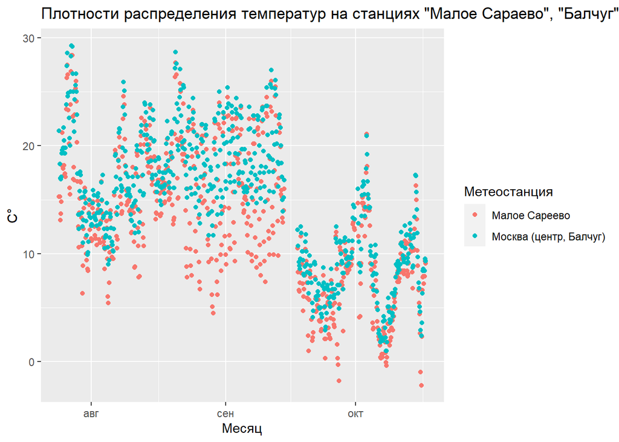

```r
ggplot(filter_data, mapping = aes(Datetime, `T`, color = NAME)) +
  geom_point() +
  ggtitle('Плотности распределения температур на станциях "Малое Сараево", "Балчуг"') +
  ylab('C°') +
  xlab('Месяц') +
  labs(color = 'Метеостанция')
```

На основе анализа построенного графика можно сказать, что для Малого Сареева характерны большее количество низких температур по сравнению с центром Москвы (Балчуг)

Построение графика плотности распределения ночных температур:

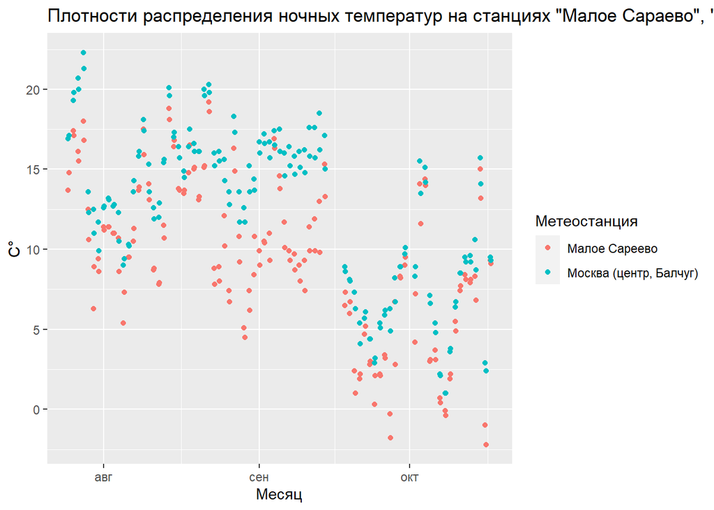

```r
ggplot(filter_data_night, mapping = aes(Datetime, `T`, color = NAME)) +
  geom_point() +
  ggtitle('Плотности распределения ночных температур на станциях "Малое Сараево", "Балчуг"') +
  ylab('C°') +
  xlab('Месяц') +
  labs(color = 'Метеостанция')
```

Построение графика boxplot (диграммы размаха) для общей выборки:

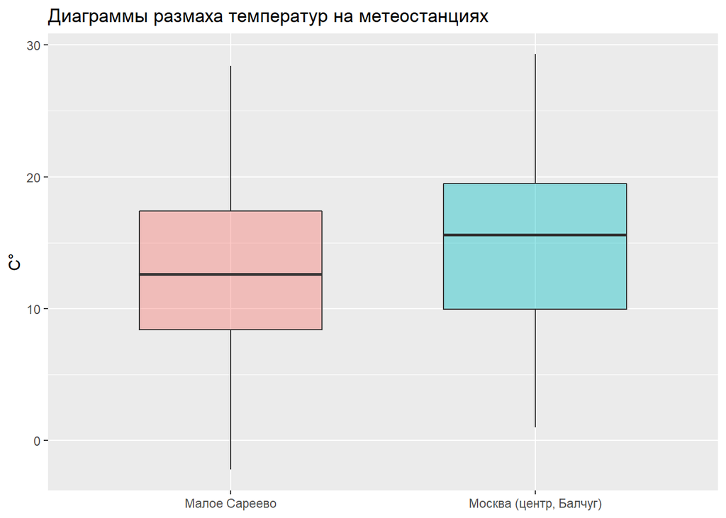

```r
ggplot(filter_data, mapping = aes(NAME, `T`, fill = NAME)) +
  geom_boxplot(alpha = 0.4, width = 0.6) +
  ylab('C°') +
  theme(axis.title.x = element_blank()) +
  ggtitle('Диаграммы размаха температур на метеостанциях') +
  theme(legend.position="none")
```

Данные диаграммы лишний раз и более отчетиливо подчериквают выявленные различия в разнице температур.

Построение графика boxplot (диграммы размаха) для ночной выборки:

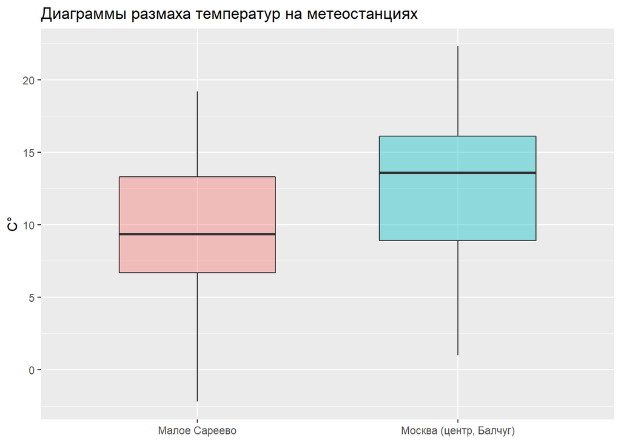

```r
ggplot(filter_data_night, mapping = aes(NAME, `T`, fill = NAME)) +
  geom_boxplot(alpha = 0.4, width = 0.6) +
  ylab('C°') +
  theme(axis.title.x = element_blank()) +
  ggtitle('Диаграммы размаха температур на метеостанциях') +
  theme(legend.position="none")
```

Данная диграмма показывает, что отличия между только ночными значениями разница средних значений больше по сравнению с общими температурами.

Применение теста Стьюдента для сравнения средних значений (общая выборка):

```r
t.test(filter_data %>% filter(ID == 27605) %>% pull(`T`),
       filter_data %>% filter(ID == 27518) %>% pull(`T`))
```

```
##
##  Welch Two Sample t-test
##
## data:  filter_data %>% filter(ID == 27605) %>% pull(T) and filter_data %>% filter(ID == 27518) %>% pull(T)
## t = 5.9192, df = 1289.4, p-value = 4.141e-09
## alternative hypothesis: true difference in means is not equal to 0
## 95 percent confidence interval:
##  1.372246 2.732770
## sample estimates:
## mean of x mean of y
##  14.87975  12.82724
```

На основе полученного p-value можно принять гипотезу о неравенстве данных выборок.

Применение теста Фишера для сравнения дисперсии (общая выборка):

```r
var.test(filter_data %>% filter(ID == 27605) %>% pull(`T`),
       filter_data %>% filter(ID == 27518) %>% pull(`T`))
```

```
##
##  F test to compare two variances
##
## data:  filter_data %>% filter(ID == 27605) %>% pull(T) and filter_data %>% filter(ID == 27518) %>% pull(T)
## F = 0.93416, num df = 646, denom df = 645, p-value = 0.3871
## alternative hypothesis: true ratio of variances is not equal to 1
## 95 percent confidence interval:
##  0.8004847 1.0901436
## sample estimates:
## ratio of variances
##          0.9341582
```

На основе полученного p-value можно сделать вывод, что в вариации не выявлено статистически значимых различий.

Применение теста Стьюдента для сравнения средних значений (ночная выборка):

```r
t.test(filter_data_night %>% filter(ID == 27605) %>% pull(`T`),
       filter_data_night %>% filter(ID == 27518) %>% pull(`T`))
```

```
##
##  Welch Two Sample t-test
##
## data:  filter_data_night %>% filter(ID == 27605) %>% pull(T) and filter_data_night %>% filter(ID == 27518) %>% pull(T)
## t = 5.6303, df = 321.97, p-value = 3.92e-08
## alternative hypothesis: true difference in means is not equal to 0
## 95 percent confidence interval:
##  1.997513 4.143228
## sample estimates:
## mean of x mean of y
## 12.502469  9.432099
```

На основе полученного p-value можно принять гипотезу о неравенстве данных выборок.

Применение теста Фишера для сравнения дисперсии (ночная выборка):

```r
var.test(filter_data_night %>% filter(ID == 27605) %>% pull(`T`),
         filter_data_night %>% filter(ID == 27518) %>% pull(`T`))
```

```
##
##  F test to compare two variances
##
## data:  filter_data_night %>% filter(ID == 27605) %>% pull(T) and filter_data_night %>% filter(ID == 27518) %>% pull(T)
## F = 1.0208, num df = 161, denom df = 161, p-value = 0.8961
## alternative hypothesis: true ratio of variances is not equal to 1
## 95 percent confidence interval:
##  0.7487052 1.3918731
## sample estimates:
## ratio of variances
##           1.020834
```

На основе полученного p-value можно сделать вывод, что в вариации не выявлено статистически значимых различий.

### Создание расчетного датафрейма (разниц температур)

Создание и преобразование датафрейма разниц температур на основе ранее скачанных данных, добавление столбцы со средней скоростью ветра:

```r
dif_df <- data.frame(Datetime = filter_data %>% filter(ID == 27605) %>% pull(Datetime)) %>%
  mutate(temp_dif = (filter_data %>% filter(ID == 27605) %>% pull(`T`) -
         filter_data %>% filter(ID == 27518) %>% pull(`T`))) %>%
  inner_join(meteo_data %>% group_by(Datetime) %>% summarise(mean_wind_spd = round(mean(Wspd, na.rm = T), 2)))
head(dif_df)
```

```
##              Datetime temp_dif mean_wind_spd
## 1 2019-07-24 15:00:00      6.1          0.96
## 2 2019-07-24 18:00:00      3.0          0.50
## 3 2019-07-24 21:00:00      3.9          0.15
## 4 2019-07-25 00:00:00      3.2          0.36
## 5 2019-07-25 03:00:00      2.3          0.56
## 6 2019-07-25 06:00:00      1.1          1.12
```

Фильтрация и создание датафрейма с ночными температурами:

```r
dif_df_night <- dif_df %>%
  filter(hour(Datetime) == 0 | hour(Datetime) == 3)
head(dif_df_night)
```

```
##              Datetime temp_dif mean_wind_spd
## 1 2019-07-25 00:00:00      3.2          0.36
## 2 2019-07-25 03:00:00      2.3          0.56
## 3 2019-07-26 00:00:00      1.9          0.88
## 4 2019-07-26 03:00:00      2.7          1.23
## 5 2019-07-27 00:00:00      4.6          0.83
## 6 2019-07-27 03:00:00      4.5          0.92
```

Построение диграммы рассеяния с линией регрессии между разницей температурой и высчитанной средней скоростью ветра в регионе (общая выборка температур):

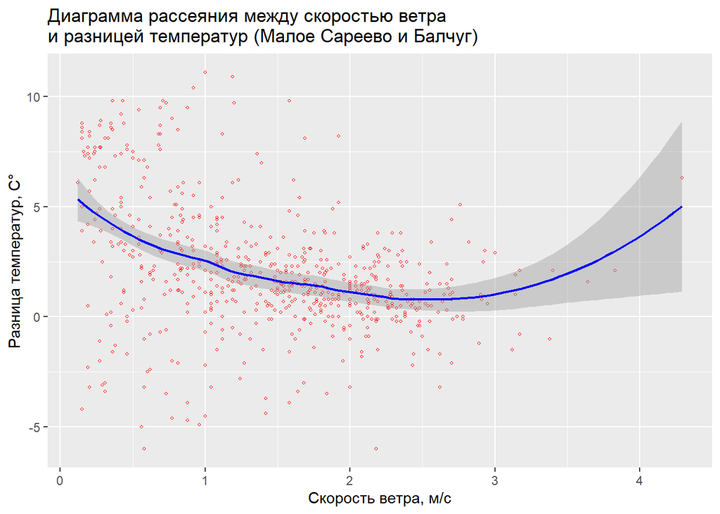

```r
ggplot(dif_df, mapping = aes(mean_wind_spd, temp_dif)) +
  geom_point(shape = 1, size = 0.8, color = 'red') +
  geom_smooth(method = 'loess', color = 'blue', size = 0.8, span = 0.5) +
  ggtitle('Диаграмма рассеяния между скоростью ветра\nи разницей температур (Малое Сареево и Балчуг)') +
  xlab('Скорость ветра, м/с') +
  ylab('Разница температур, C°')
```

Построение диграммы рассеяния с линией регрессии между разницей температурой и высчитанной средней скоростью ветра в регионе (ночные температуры):

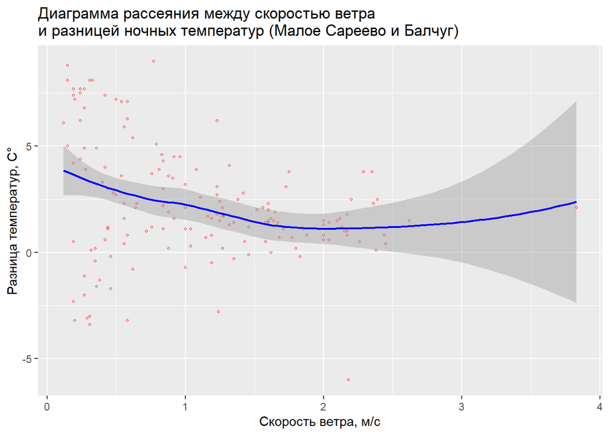

```r
ggplot(dif_df_night, mapping = aes(mean_wind_spd, temp_dif)) +
  geom_point(shape = 1, size = 0.8, color = 'red') +
  geom_smooth(method = 'loess', color = 'blue', size = 0.8, span = 0.9) +
  ggtitle('Диаграмма рассеяния между скоростью ветра\nи разницей ночных температур (Малое Сареево и Балчуг)') +
  xlab('Скорость ветра, м/с') +
  ylab('Разница температур, C°')
```

Между двумя показателями можно выявить нелинейную регрессию - при наименьших скоростях ветра отмечаются наибольшие разницы температур.

Для применения коррелляцианных тестов необходимо провести линеаризацию (сделать регрессию линейной). Для этого был выбран способ логарифмирования одного из аргументов, в данном случае этот способ подходит больше всего.

Для общей выборки:

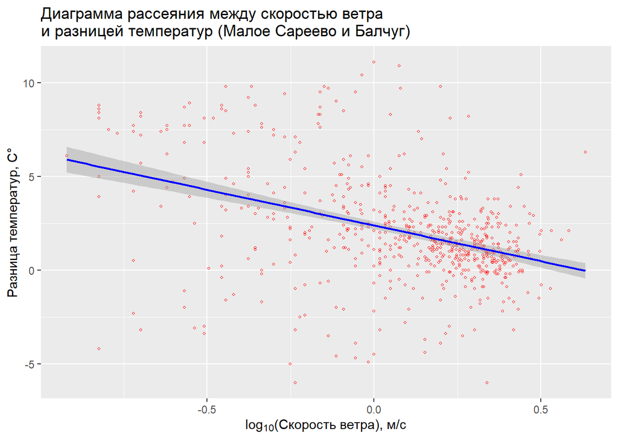

```r
ggplot(dif_df, mapping = aes(log10(mean_wind_spd), temp_dif)) +
  geom_point(shape = 1, size = 0.8, color = 'red') +
  geom_smooth(method = 'lm', color = 'blue', size = 0.8) +
  ggtitle('Диаграмма рассеяния между скоростью ветра\nи разницей температур (Малое Сареево и Балчуг)') +
  xlab(expression('log'[10]*'(Скорость ветра), м/с')) +
  ylab('Разница температур, C°')
```

Для ночной выборки:

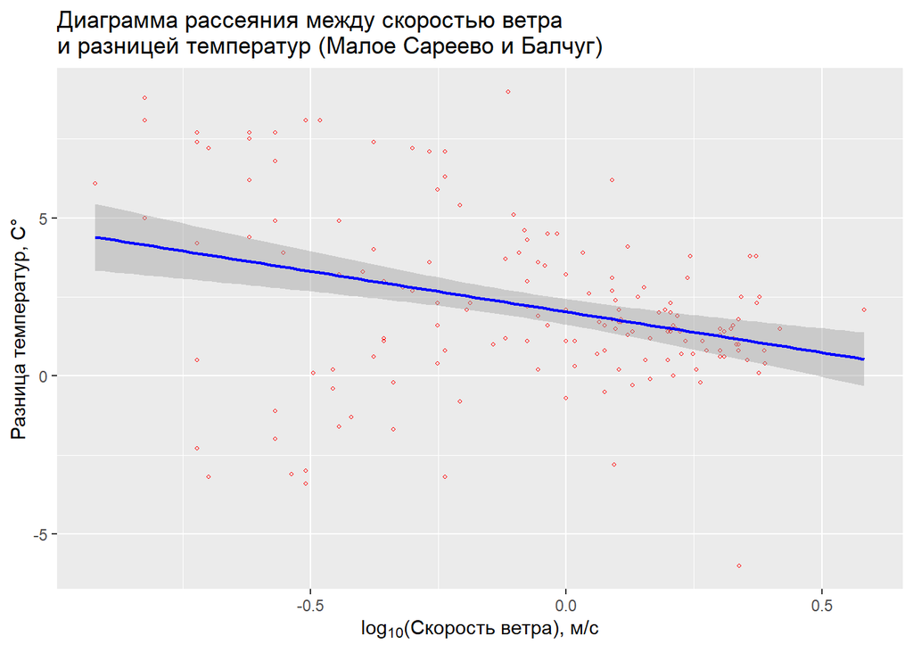

```r
ggplot(dif_df_night, mapping = aes(log10(mean_wind_spd), temp_dif)) +
  geom_point(shape = 1, size = 0.8, color = 'red') +
  geom_smooth(method = 'lm', color = 'blue', size = 0.8) +
  ggtitle('Диаграмма рассеяния между скоростью ветра\nи разницей температур (Малое Сареево и Балчуг)') +
  xlab(expression('log'[10]*'(Скорость ветра), м/с')) +
  ylab('Разница температур, C°')
```

### Проведение корреляционного теста и получение линейной модели регрессии

Проведение корреляционного теста (Пирсона) для общей выборки:

```r
cor.test(log10(dif_df$mean_wind_spd), dif_df$temp_dif)
```

```
##
##  Pearson's product-moment correlation
##
## data:  log10(dif_df$mean_wind_spd) and dif_df$temp_dif
## t = -11.441, df = 644, p-value < 2.2e-16
## alternative hypothesis: true correlation is not equal to 0
## 95 percent confidence interval:
##  -0.4731449 -0.3447980
## sample estimates:
##        cor
## -0.4110061
```

На основе полученных данных можно сказать что величины имеют незначительную обратную связь, так как значение всего -0.41.

Проведение корреляционного теста для ночной выборки:

```r
cor.test(log10(dif_df_night$mean_wind_spd), dif_df_night$temp_dif)
```

```
##
##  Pearson's product-moment correlation
##
## data:  log10(dif_df_night$mean_wind_spd) and dif_df_night$temp_dif
## t = -4.4043, df = 159, p-value = 1.942e-05
## alternative hypothesis: true correlation is not equal to 0
## 95 percent confidence interval:
##  -0.4609137 -0.1844815
## sample estimates:
##        cor
## -0.3297471
```

Выявлена незначительная обратная связь. Можно отметить, что в ночное время связь менее значительна (-0.33).

Получение модели линейной регрессии:

```r
linear_model = lm(log10(dif_df$mean_wind_spd) ~ dif_df$temp_dif)
summary(linear_model)
```

```
##
## Call:
## lm(formula = log10(dif_df$mean_wind_spd) ~ dif_df$temp_dif)
##
## Residuals:
##      Min       1Q   Median       3Q      Max
## -1.18756 -0.12865  0.07516  0.19428  0.73414
##
## Coefficients:
##                  Estimate Std. Error t value Pr(>|t|)
## (Intercept)      0.177517   0.013488   13.16   <2e-16 ***
## dif_df$temp_dif -0.044318   0.003874  -11.44   <2e-16 ***
## ---
## Signif. codes:  0 '***' 0.001 '**' 0.01 '*' 0.05 '.' 0.1 ' ' 1
##
## Residual standard error: 0.2771 on 644 degrees of freedom
##   (1 observation deleted due to missingness)
## Multiple R-squared:  0.1689, Adjusted R-squared:  0.1676
## F-statistic: 130.9 on 1 and 644 DF,  p-value: < 2.2e-16
```

Получени данные: коэффициенты, интервал и статистика по отклонениям, среднеквадратическое отклонение и др.